# hmwrk4.2

student

2023-09-06

## Clustering

**Summary**

*R code performs k-means clustering on the Iris dataset to find the best combination of predictors and the optimal number of clusters(k).* *Best result found that using “Sepal.Width” as a predictor and k=2 clusters minimized the within-cluster sum of squares (WSS), with Setosa flower type.*

## Begin Code

Load Libraries

```r
library(ggplot2)
```

Load Data

```r
# load the Iris data
data(iris)
```

Elbow Method: find_elbow function attempts to find a point where the decrease in WSS starts to slow down looks like an “elbow”, and this is taken as a good indication of the appropriate number of clusters to use.

```r
# create the find_elbow function
find_elbow <- function(wss_values) {
  # elbow finding logic here
  diff_wss <- diff(wss_values)
  diff_ratio <- diff(diff_wss)
  # +1 as diff reduces the length by 1
  return (which.max(diff_ratio) + 1)
}
```

Create Variables

```r
# variables to store the best results
best_wss <- Inf
best_k <- NA
best_predictors <- NULL
```

Number of predictors: 4, “Sepal.Length”, “Sepal.Width”, “Petal.Length”, and “Petal.Width”.

```r
# number of predictors
n_predictors <- ncol(iris[, 1:4])
```

**Loop through predictions and find the best k, print graph.**

*X-axis: the number of clusters you are using for that particular k-means run.*

*Y-axis:Within-cluster sum of squares (WSS): the total distance of each point to its cluster centroid, lower values may mean that the data points are closer to the centroids, which usually means better clustering.*

*Points/Lines: Each point represents the WSS value for a specific k.*

*Color Gradient: The color indicates the value of k, going from blue (smaller k) to red (larger k).*

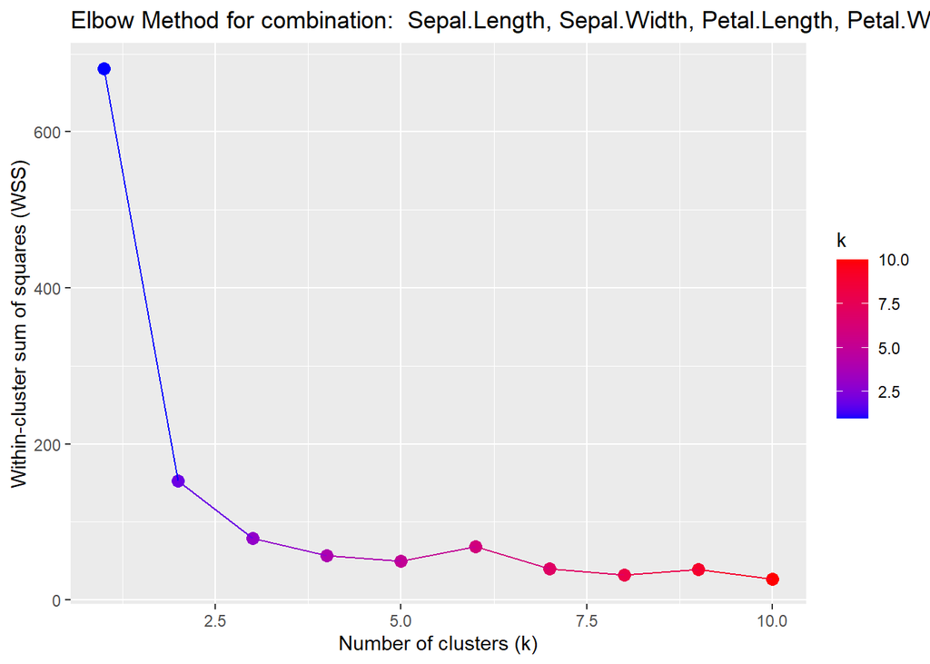

```r
# loop through all non-empty combinations of predictors
for (n in 1:n_predictors) {
  combinations <- combn(1:n_predictors, n)
  n_combinations <- ncol(combinations)

  for (i in 1:n_combinations) {
    predictors <- combinations[, i]
    # initialize WSS array
    wss <- numeric(10)

    # find the best 'k' for the current combination
    for (k in 1:10) {
      km_out <- kmeans(iris[, predictors], centers=k)
      wss[k] <- km_out$tot.withinss
    }

    # use the elbow method to find the optimal k for this combination
    optimal_k <- find_elbow(wss)

    # plot elbow graph
    plot = ggplot(data.frame(k = 1:10, WSS = wss), aes(x = k, y = WSS)) +
    geom_point(aes(color = k), size = 3) +
    geom_line(aes(color = k)) +
    scale_color_gradient(low = "#0000FF", high = "#FF0000") +
    ggtitle(paste("Elbow Method for combination: ", paste(colnames(iris)[predictors], collapse = ", "))) +
    xlab("Number of clusters (k)") +
    ylab("Within-cluster sum of squares (WSS)")

    # check if the current combination is better
    if (wss[optimal_k] < best_wss) {
      best_wss <- wss[optimal_k]
      best_k <- optimal_k
      best_predictors <- predictors
    }
  }
}
print(plot)
```

Print Results

```r
# print the best results
cat("Best WSS:", best_wss, "\n")
```

```
## Best WSS: 12.32171
```

```r
cat("Best k:", best_k, "\n")
```

```
## Best k: 2
```

```r
cat("Best predictors:", colnames(iris)[best_predictors], "\n")
```

```
## Best predictors: Sepal.Width
```

**View Possible Flower Type: Setosa is found to have the best match according my findings.**

```r
# load the Iris data
data(iris)

# perform k-means clustering using Sepal.Width and k = 2
km_out <- kmeans(iris[, "Sepal.Width", drop = FALSE], centers = 2)

# add the cluster assignments back to the original Iris data frame
iris$Cluster <- km_out$cluster

# view the data with cluster assignments
head(iris)
```

```
##   Sepal.Length Sepal.Width Petal.Length Petal.Width Species Cluster
## 1          5.1         3.5          1.4         0.2  setosa       1
## 2          4.9         3.0          1.4         0.2  setosa       2
## 3          4.7         3.2          1.3         0.2  setosa       1
## 4          4.6         3.1          1.5         0.2  setosa       1
## 5          5.0         3.6          1.4         0.2  setosa       1
## 6          5.4         3.9          1.7         0.4  setosa       1
```

```r
# cluster assignments vs actual flower types
table(iris$Cluster, iris$Species)
```

```
##
##     setosa versicolor virginica
##   1     42          8        17
##   2      8         42        33
```